[interactive chart not shown]

# Network plots

For all of these, I did a little bit of cleaning. I aligned these words: “american” ~ “america”, “historical” ~ “history”, “changes” ~ “change”, “climatic” ~ “climate”, “ecological” ~ “ecology”, “mammalian” ~ “mammal”, “mammals” ~ “mammal”, “middens” ~ “midden”, and “diversity” ~ “biodiversity”

And I removed all these words: “to”, “from”, “and”, “for”, “in”, “the”, “that”, “were”, “of”, “a”, “an”, “at”, “on”,“with”, “are”, “is”, “bp”, “have”, “two”, “de”, “can”, “by”, “how”, “as”, “new”, “small”, “en”, “when”, “top”, “role”, “first”, “effects”, “using”

This network tries to show everything, but it’s messy:

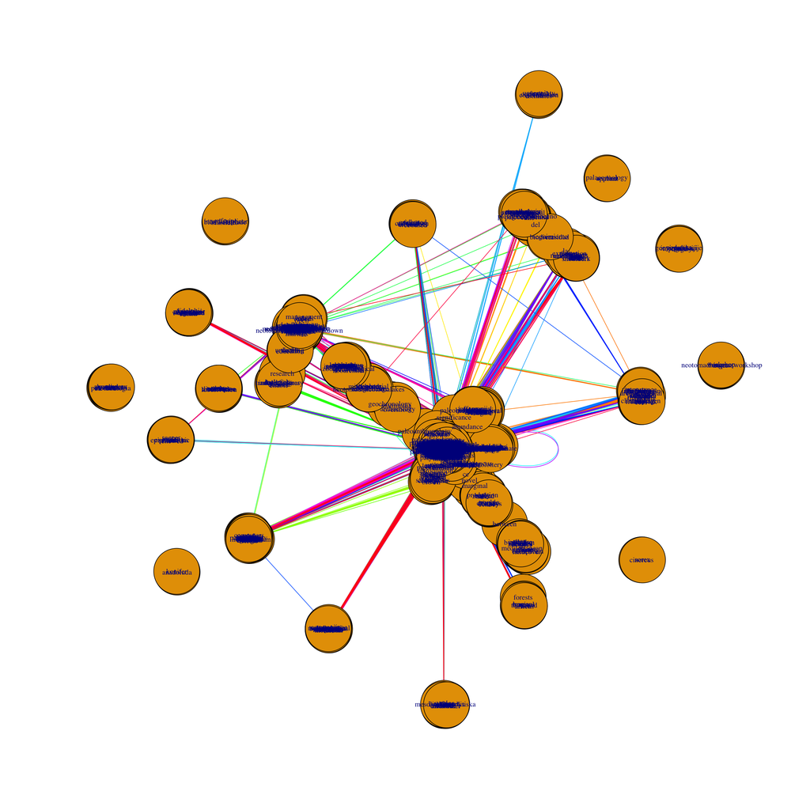

So I tried to simplify the networks in a few different ways.

1. This first graph shows only the paths greater than weight 1

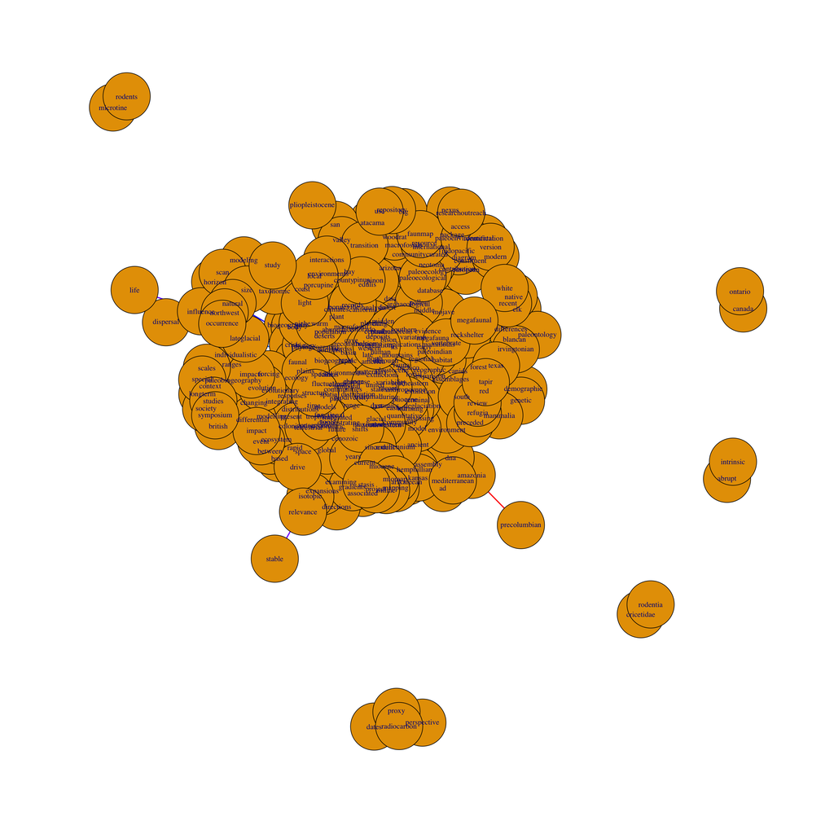

2. This second graph shows just those connections greater than weight 2

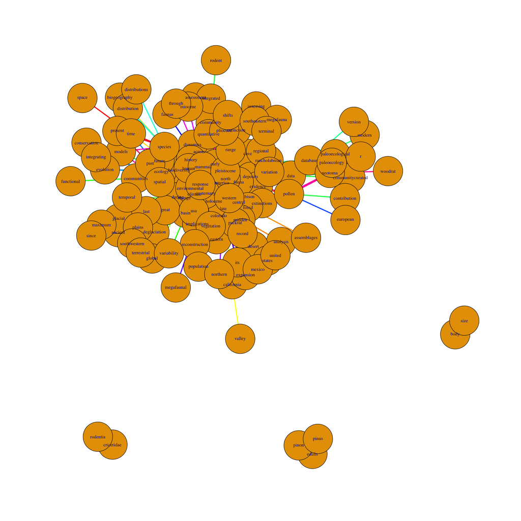

3. This third graph shows just those connections greater than weight 3.

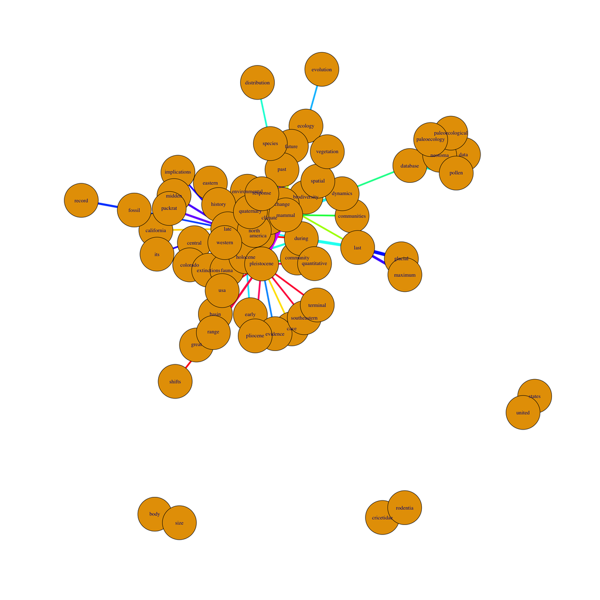

4. And this fourth graph shows just those connections greater than weight 4.

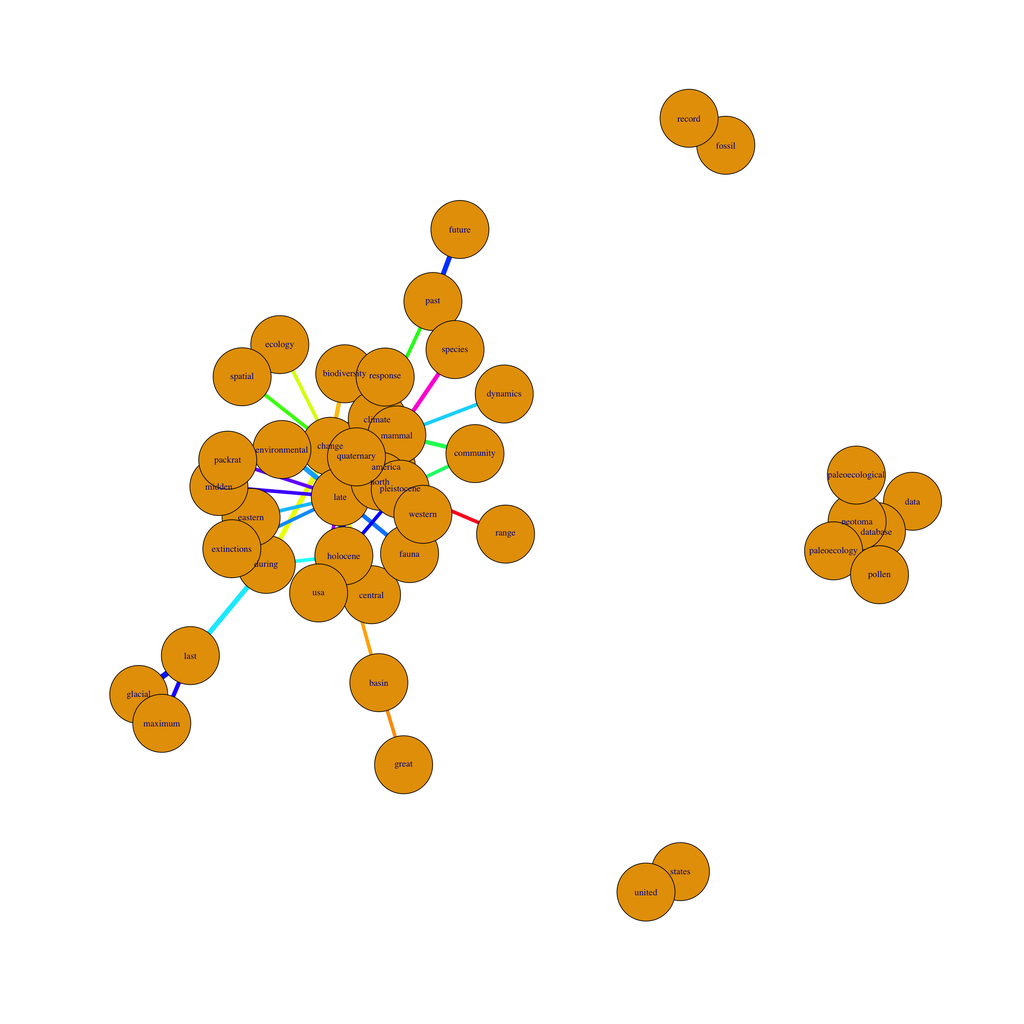

Then I chose a set of commonly occurring words I thought were interesting and did a similar set of networks:

1. The first one is all the connections among a set of commonly occurring words I thought were interesting.
2. The second one is the connections greater than weight 1 of the same set of commonly occurring words I thought were interesting.
3. The third one is the connections greater than weight 2 of the same set of commonly occurring words I thought were interesting.

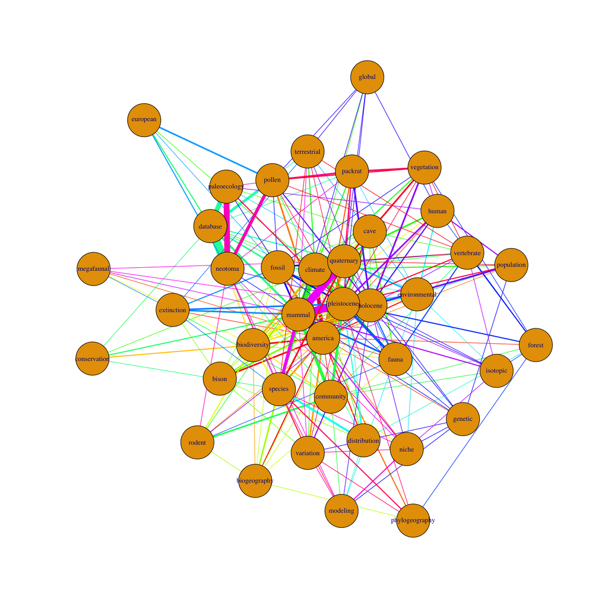

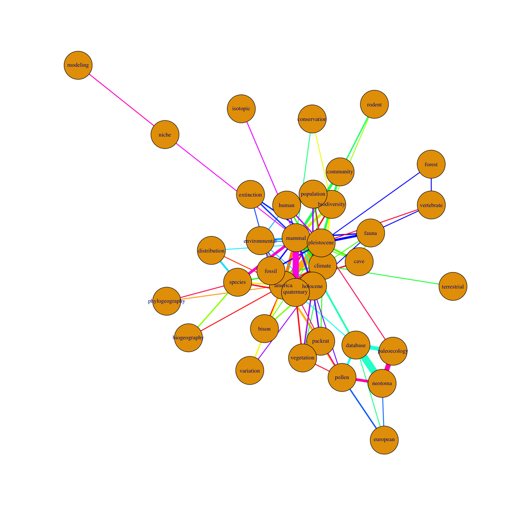

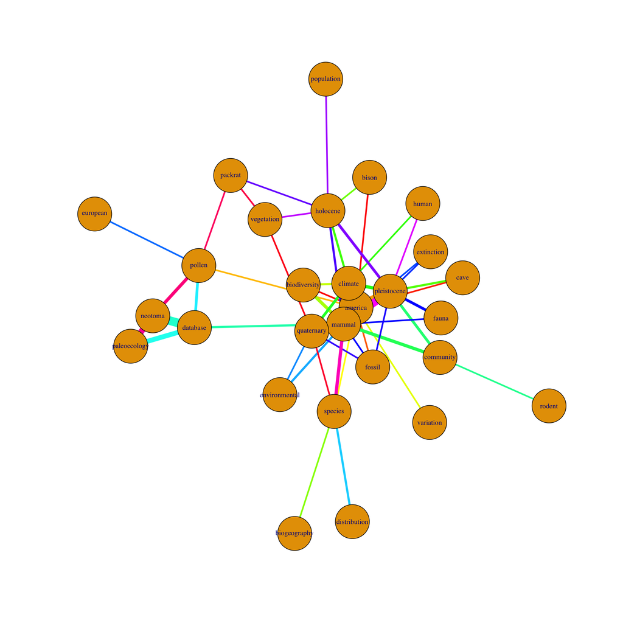

Some metrics on the full dataset:

Degree centrality - number of direct connections each node has

|  | deg |
| --- | --- |
| late | 310 |
| pleistocene | 281 |
| america | 276 |
| north | 256 |
| change | 252 |
| mammal | 243 |
| climate | 227 |
| holocene | 197 |
| data | 174 |
| quaternary | 165 |

[output cut: 1474 more lines]

Betweenness:

|  | btw |
| --- | --- |
| late | 0.05820365474942511 |
| data | 0.0563245405419187 |
| change | 0.05459502718540955 |
| climate | 0.05119820100774693 |
| pleistocene | 0.05027654276458664 |
| america | 0.04142060268849478 |
| north | 0.03887351908295251 |
| fossil | 0.03650447033242261 |
| biodiversity | 0.03328892019515231 |
| holocene | 0.0308676820782916 |

[output cut: 1474 more lines]

Closeness:

|  | clo |
| --- | --- |
| abordagem | 1 |
| anadoluda | 1 |
| applied | 1 |
| biodiversidade | 1 |
| brasileiro | 1 |
| cinereus | 1 |
| congress | 1 |
| das | 1 |
| em | 1 |
| enfoque | 1 |

[output cut: 1474 more lines]

Eigenvector Centrality:

|  | eig |
| --- | --- |
| late | 1 |
| america | 0.959557581105008 |
| north | 0.9301725255859564 |
| pleistocene | 0.859878230086959 |
| mammal | 0.8545779909659589 |
| change | 0.6942003660291738 |
| climate | 0.6125381775042671 |
| quaternary | 0.6062742798840622 |
| holocene | 0.4228198296529077 |
| during | 0.317828659484201 |

[output cut: 1474 more lines]